# Reto 1

Blockchain Patrol

2023-11-06

# Crypto Datathon Reto 1

```r
library(data.table)
library(tidyverse)
library(readr)
library(ggplot2)
library(PerformanceAnalytics)
library(dygraphs)
library(tidyr)
library(cluster)
library(NbClust)
library(fpc)
library(factoextra)
library(corrplot)
```

## Carga y limpieza de los datos

Cargamos en primer lugar la información cualitativa de las monedas. Para ello incluimos una carpeta “Data” con los ficheros al mismo nivel de ejecución de este fichero RMD

```r
info_cualitativa <- read_csv2('./Data/informacion_cualitativa_monedas_reto1.csv', show_col_types = FALSE)
str(info_cualitativa)
```

```
## spc_tbl_ [8,656 × 23] (S3: spec_tbl_df/tbl_df/tbl/data.frame)
##  $ ...1                    : num [1:8656] 0 1 2 3 4 5 6 7 8 9 ...
##  $ Id                      : num [1:8656] 1182 3808 3807 5038 1183 ...
##  $ Name                    : chr [1:8656] "BTC" "LTC" "DASH" "XMR" ...
##  $ Symbol                  : chr [1:8656] "BTC" "LTC" "DASH" "XMR" ...
##  $ CoinName                : chr [1:8656] "Bitcoin" "Litecoin" "Dash" "Monero" ...
##  $ FullName                : chr [1:8656] "Bitcoin (BTC)" "Litecoin (LTC)" "Dash (DASH)" "Monero (XMR)" ...
##  $ Description             : chr [1:8656] "What is Bitcoin?Bitcoin (BTC) is the first successful decentralized cryptocurrency. It uses peer-to-peer techno"| __truncated__ "What is Litecoin (LTC)?Litecoin (LTC) is widely seen as the first successful alternative cryptocurrency (altcoi"| __truncated…
##  $ AssetTokenStatus        : chr [1:8656] "N/A" "N/A" "N/A" "N/A" ...
##  $ Algorithm               : chr [1:8656] "SHA-256" "Scrypt" "X11" "RandomX" ...
##  $ ProofType               : chr [1:8656] "PoW" "PoW" "PoW/PoSe" "PoW" ...
##  $ SortOrder               : num [1:8656] 1 3 4 5 6 7 8 9 10 11 ...
##  $ Sponsored               : logi [1:8656] FALSE FALSE FALSE FALSE FALSE FALSE ...
##  $ Access                  : chr [1:8656] "Permissionless" "Permissionless" "Permissionless" "Permissionless" ...
##  $ FCA                     : chr [1:8656] "Exchange" "Exchange" "Exchange" "Exchange" ...
##  $ FINMA                   : chr [1:8656] "Payment" "Payment" "Payment" "Payment" ...
##  $ Industry                : chr [1:8656] "Financial and Insurance Activities" "Financial and Insurance Activities" "Financial and Insurance Activities" "Financial and Insurance Activities" ...
##  $ CollateralizedAsset     : chr [1:8656] "No" "No" "No" "No" ...
##  $ CollateralizedAssetType : chr [1:8656] NA NA NA NA ...
##  $ CollateralType          : chr [1:8656] NA NA NA NA ...
##  $ CollateralInfo          : logi [1:8656] NA NA NA NA NA NA ...
##  $ Rating                  : chr [1:8656] "B+" "B-" "C+" "C" ...
##  $ TechnologyAdoptionRating: chr [1:8656] "A-" "B" "B-" "C" ...
##  $ MarketPerformanceRating : chr [1:8656] "D" "D" "D-" "D" ...
##  - attr(*, "spec")=
##   .. cols(
##   ..   ...1 = col_double(),
##   ..   Id = col_double(),
##   ..   Name = col_character(),
##   ..   Symbol = col_character(),
##   ..   CoinName = col_character(),
##   ..   FullName = col_character(),
##   ..   Description = col_character(),
##   ..   AssetTokenStatus = col_character(),
##   ..   Algorithm = col_character(),
##   ..   ProofType = col_character(),
##   ..   SortOrder = col_double(),
##   ..   Sponsored = col_logical(),
##   ..   Access = col_character(),
##   ..   FCA = col_character(),
##   ..   FINMA = col_character(),
##   ..   Industry = col_character(),
##   ..   CollateralizedAsset = col_character(),
##   ..   CollateralizedAssetType = col_character(),
##   ..   CollateralType = col_character(),
##   ..   CollateralInfo = col_logical(),
##   ..   Rating = col_character(),
##   ..   TechnologyAdoptionRating = col_character(),
##   ..   MarketPerformanceRating = col_character()
##   .. )
##  - attr(*, "problems")=<externalptr>
```

Y hacemos una primera inspección de los resultados.

```r
summary(info_cualitativa)
```

```
##       ...1            Id             Name              Symbol
##  Min.   :   0   Min.   :  1182   Length:8656        Length:8656
##  1st Qu.:2164   1st Qu.:819796   Class :character   Class :character
##  Median :4328   Median :934990   Mode  :character   Mode  :character
##  Mean   :4328   Mean   :761846
##  3rd Qu.:6491   3rd Qu.:944737
##  Max.   :8655   Max.   :954078
##    CoinName           FullName         Description        AssetTokenStatus
##  Length:8656        Length:8656        Length:8656        Length:8656
##  Class :character   Class :character   Class :character   Class :character
##  Mode  :character   Mode  :character   Mode  :character   Mode  :character
##
##
##
##   Algorithm          ProofType           SortOrder     Sponsored
##  Length:8656        Length:8656        Min.   :    1   Mode :logical
##  Class :character   Class :character   1st Qu.: 2486   FALSE:8656
##  Mode  :character   Mode  :character   Median : 5158
##                                        Mean   : 5226
##                                        3rd Qu.: 7951
##                                        Max.   :10176
##     Access              FCA               FINMA             Industry
##  Length:8656        Length:8656        Length:8656        Length:8656
##  Class :character   Class :character   Class :character   Class :character
##  Mode  :character   Mode  :character   Mode  :character   Mode  :character
##
##
##
##  CollateralizedAsset CollateralizedAssetType CollateralType     CollateralInfo
##  Length:8656         Length:8656             Length:8656        Mode:logical
##  Class :character    Class :character        Class :character   NA's:8656
##  Mode  :character    Mode  :character        Mode  :character
##
##
##
##     Rating          TechnologyAdoptionRating MarketPerformanceRating
##  Length:8656        Length:8656              Length:8656
##  Class :character   Class :character         Class :character
##  Mode  :character   Mode  :character         Mode  :character
##
##
##
```

Ahora cargamos la información cuantitativa de monedas en un único dataset.

```r
info_cuantitativa <-
  list.files(path = 'Data/Información cuantitativa monedas_reto1', pattern = "*.csv", full.names = TRUE, recursive = TRUE) %>%
  map_df(~fread(.x, drop = 'V1') %>% add_column(Currency = sub(pattern = "(.*)\\..*$", replacement = "\\1", basename(.x)), .before = 0))

str(info_cuantitativa)
```

```
## Classes 'data.table' and 'data.frame':   95505 obs. of  9 variables:
##  $ Currency          : chr  "Aeternity" "Aeternity" "Aeternity" "Aeternity" ...
##  $ Date              : IDate, format: "2021-12-06" "2021-12-05" ...
##  $ Open              : num  0.14 0.137 0.151 0.172 0.197 ...
##  $ High              : num  0.142 0.142 0.151 0.173 0.197 ...
##  $ Low               : num  0.128 0.133 0.122 0.151 0.169 ...
##  $ Close             : num  0.14 0.14 0.14 0.151 0.172 ...
##  $ Volume            : num  6178135 5473800 7756797 8610311 6711529 ...
##  $ Market Cap        : num  48816648 48565153 48594743 52546896 59656315 ...
##  $ Circulating Supply: num  3.48e+08 3.48e+08 3.48e+08 3.48e+08 3.47e+08 ...
##  - attr(*, ".internal.selfref")=<externalptr>
```

Y de nuevo visualizamos los resultados.

```r
summary(info_cuantitativa)
```

```
##    Currency              Date                 Open               High
##  Length:95505       Min.   :2015-06-01   Min.   :    0.00   Min.   :       0
##  Class :character   1st Qu.:2019-07-27   1st Qu.:    0.02   1st Qu.:       0
##  Mode  :character   Median :2020-07-29   Median :    0.20   Median :       0
##                     Mean   :2020-05-02   Mean   :  263.18   Mean   :     427
##                     3rd Qu.:2021-04-26   3rd Qu.:    1.70   3rd Qu.:       2
##                     Max.   :2022-01-02   Max.   :67549.74   Max.   :14535422
##
##       Low               Close              Volume            Market Cap
##  Min.   :    0.00   Min.   :    0.00   Min.   :0.000e+00   Min.   :0.000e+00
##  1st Qu.:    0.02   1st Qu.:    0.02   1st Qu.:5.780e+05   1st Qu.:1.460e+07
##  Median :    0.18   Median :    0.20   Median :3.389e+06   Median :5.601e+07
##  Mean   :  254.61   Mean   :  263.72   Mean   :6.753e+08   Mean   :6.351e+09
##  3rd Qu.:    1.60   3rd Qu.:    1.71   3rd Qu.:3.005e+07   3rd Qu.:2.423e+08
##  Max.   :66382.06   Max.   :67566.83   Max.   :3.510e+11   Max.   :1.275e+12
##
##  Circulating Supply
##  Min.   :0.000e+00
##  1st Qu.:5.024e+07
##  Median :2.404e+08
##  Mean   :2.063e+12
##  3rd Qu.:1.143e+09
##  Max.   :5.577e+14
##  NA's   :129
```

Calculamos el rendimiendo diario (total y en porcentaje). Los vamos a utilizar luego para las métricas y para análisis posteriores.

Rendimiento Diario = [(Precio de Cierre Actual - Precio de Cierre del Día Anterior) / Precio de Cierre del Día Anterior] * 100

```r
info_cuantitativa <- info_cuantitativa %>%
  group_by(Currency) %>%
  arrange(Date) %>%
  mutate(Return = Close - lag(Close)) %>%
  mutate(Return_Pctg = 100*(Close - lag(Close))/lag(Close))

# Sustituimos los valores que son NaN e Inf por NA
info_cuantitativa$Return[is.nan(info_cuantitativa$Return)] <- NA
info_cuantitativa$Return_Pctg[is.nan(info_cuantitativa$Return_Pctg)] <- NA
info_cuantitativa$Return[is.infinite(info_cuantitativa$Return)] <- NA
info_cuantitativa$Return_Pctg[is.infinite(info_cuantitativa$Return_Pctg)] <- NA

summary(info_cuantitativa)
```

```
##    Currency              Date                 Open               High
##  Length:95505       Min.   :2015-06-01   Min.   :    0.00   Min.   :       0
##  Class :character   1st Qu.:2019-07-27   1st Qu.:    0.02   1st Qu.:       0
##  Mode  :character   Median :2020-07-29   Median :    0.20   Median :       0
##                     Mean   :2020-05-02   Mean   :  263.18   Mean   :     427
##                     3rd Qu.:2021-04-26   3rd Qu.:    1.70   3rd Qu.:       2
##                     Max.   :2022-01-02   Max.   :67549.74   Max.   :14535422
##
##       Low               Close              Volume            Market Cap
##  Min.   :    0.00   Min.   :    0.00   Min.   :0.000e+00   Min.   :0.000e+00
##  1st Qu.:    0.02   1st Qu.:    0.02   1st Qu.:5.780e+05   1st Qu.:1.460e+07
##  Median :    0.18   Median :    0.20   Median :3.389e+06   Median :5.601e+07
##  Mean   :  254.61   Mean   :  263.72   Mean   :6.753e+08   Mean   :6.351e+09
##  3rd Qu.:    1.60   3rd Qu.:    1.71   3rd Qu.:3.005e+07   3rd Qu.:2.423e+08
##  Max.   :66382.06   Max.   :67566.83   Max.   :3.510e+11   Max.   :1.275e+12
##
##  Circulating Supply      Return           Return_Pctg
##  Min.   :0.000e+00   Min.   :-7554.040   Min.   :-100.0000
##  1st Qu.:5.024e+07   1st Qu.:   -0.007   1st Qu.:  -3.6364
##  Median :2.404e+08   Median :    0.000   Median :  -0.0434
##  Mean   :2.063e+12   Mean   :    0.571   Mean   :   0.6180
##  3rd Qu.:1.143e+09   3rd Qu.:    0.006   3rd Qu.:   3.5442
##  Max.   :5.577e+14   Max.   : 7293.020   Max.   : 695.3297
##  NA's   :129         NA's   :107         NA's   :236
```

La columna ‘Circulating Supply’ tiene 129 valores NA. Vemos que corresponden a la moneda SHIBA INU y son filas en las que todos los datos son 0, salvo el volumen. Como parece que no tiene mucho sentido, vamos a eliminar estas 129 filas.

```r
info_cuantitativa <- info_cuantitativa  %>%
  drop_na(`Circulating Supply`)

summary(info_cuantitativa)
```

```
##    Currency              Date                 Open               High
##  Length:95376       Min.   :2015-06-01   Min.   :    0.00   Min.   :       0
##  Class :character   1st Qu.:2019-07-26   1st Qu.:    0.03   1st Qu.:       0
##  Mode  :character   Median :2020-07-28   Median :    0.20   Median :       0
##                     Mean   :2020-05-02   Mean   :  263.54   Mean   :     427
##                     3rd Qu.:2021-04-27   3rd Qu.:    1.71   3rd Qu.:       2
##                     Max.   :2022-01-02   Max.   :67549.74   Max.   :14535422
##
##       Low               Close              Volume            Market Cap
##  Min.   :    0.00   Min.   :    0.00   Min.   :0.000e+00   Min.   :0.000e+00
##  1st Qu.:    0.02   1st Qu.:    0.03   1st Qu.:5.836e+05   1st Qu.:1.471e+07
##  Median :    0.18   Median :    0.20   Median :3.403e+06   Median :5.619e+07
##  Mean   :  254.96   Mean   :  264.08   Mean   :6.762e+08   Mean   :6.360e+09
##  3rd Qu.:    1.60   3rd Qu.:    1.71   3rd Qu.:3.018e+07   3rd Qu.:2.432e+08
##  Max.   :66382.06   Max.   :67566.83   Max.   :3.510e+11   Max.   :1.275e+12
##
##  Circulating Supply      Return           Return_Pctg
##  Min.   :0.000e+00   Min.   :-7554.040   Min.   :-93.3150
##  1st Qu.:5.024e+07   1st Qu.:   -0.007   1st Qu.: -3.6364
##  Median :2.404e+08   Median :    0.000   Median : -0.0434
##  Mean   :2.063e+12   Mean   :    0.572   Mean   :  0.6190
##  3rd Qu.:1.143e+09   3rd Qu.:    0.006   3rd Qu.:  3.5442
##  Max.   :5.577e+14   Max.   : 7293.020   Max.   :695.3297
##                      NA's   :107         NA's   :108
```

Ahora ya sólo tenemos valores NA en las columnas donde hemos calculado el retorno, pero esto es normal ya que para el primer día para el que tenemos datos no se puede calcular este valor.

## Análisis de datos

Vamos a crear un dataset donde almacenar las variables cuantitativas de cada cripto.

```r
crypto_summary_by_currency <- info_cuantitativa %>%
  group_by(Currency) %>%
  summarise(`Market Cap` = mean(`Market Cap`), Volume = mean(Volume), Volatility = sd(Return_Pctg, na.rm=TRUE))

crypto_summary_by_currency
```

```
## # A tibble: 107 × 4
##    Currency   `Market Cap`     Volume Volatility
##    <chr>             <dbl>      <dbl>      <dbl>
##  1 ASTA          34041568    2196174.       9.76
##  2 AXEL          54294636.    286012.       5.19
##  3 Aeternity    143351071.  15175843.       9.47
##  4 Aion          95538156.   7206512.       9.29
##  5 Algorand    1965513225. 217976950.       7.44
##  6 Auto          51258578.  10969040.      13.9
##  7 Avalanche   5120268863. 448324579.       9.16
##  8 BORA          76378679.  36576020.      16.6
##  9 BarnBridge    84200321.  10515092.       9.04
## 10 BitTorrent   897696092. 299455309.       7.35
## # ℹ 97 more rows
```

### Top 10

Vamos a visualizar las 10 criptos más destacadas por cada uno de los parámetros.

```r
top_cap <- info_cuantitativa %>%
  group_by(Currency) %>%
  summarise(`Market Cap` = mean(`Market Cap`)) %>%
  top_n(10, `Market Cap`) %>%
  arrange(desc(`Market Cap`))

top_cap
```

```
## # A tibble: 10 × 2
##    Currency   `Market Cap`
##    <chr>             <dbl>
##  1 Bitcoin   426645855980.
##  2 Ethereum  146145441996.
##  3 Solana     11759289940.
##  4 HEX        10930759390.
##  5 Dogecoin   10884203807.
##  6 Litecoin    7110302815.
##  7 Avalanche   5120268863.
##  8 SHIBA INU   5084952863.
##  9 TRON        2631645046.
## 10 Polygon     2236730408.
```

Por volumen

```r
top_volume <- info_cuantitativa %>%
  group_by(Currency) %>%
  summarise(Volume = mean(Volume)) %>%
  top_n(10, Volume) %>%
  arrange(desc(Volume))

top_volume
```

```
## # A tibble: 10 × 2
##    Currency               Volume
##    <chr>                   <dbl>
##  1 Bitcoin          34705857207.
##  2 Ethereum         18955317547.
##  3 Litecoin          3899987001.
##  4 Dogecoin          1795843698.
##  5 SHIBA INU         1485184754.
##  6 Ethereum Classic  1454327253.
##  7 TRON              1012361923.
##  8 Solana             841911615.
##  9 Neo                533609472.
## 10 Qcash              502981629.
```

Por volatilidad (se mide como la desviación estándar del retorno diario. El retorno se calcula como el precio de cierre del menos el precio de cierre del día anterior dividido entre el precio de cierre del día anterior)

```r
top_volatility <- info_cuantitativa %>%
  group_by(Currency) %>%
  summarize(Volatility = sd(Return_Pctg, na.rm=TRUE)) %>%
  top_n(10, Volatility) %>%
  arrange(desc(Volatility))

top_volatility
```

```
## # A tibble: 10 × 2
##    Currency     Volatility
##    <chr>             <dbl>
##  1 SHIBA INU          37.3
##  2 HEX                29.1
##  3 Dogelon Mars       27.4
##  4 Lightning          22.3
##  5 Gala               20.8
##  6 Lotto              18.4
##  7 MCO                17.4
##  8 Mist               17.4
##  9 Bread              17.1
## 10 BORA               16.6
```

## Gráficas

Nos quedamos con las diez acciones que tienen más capitalización de mercado.

```r
info_cuantitativa_top <- filter(info_cuantitativa, Currency %in% top_cap$Currency)
```

Mostramos la gráfica de evolución de los precios.

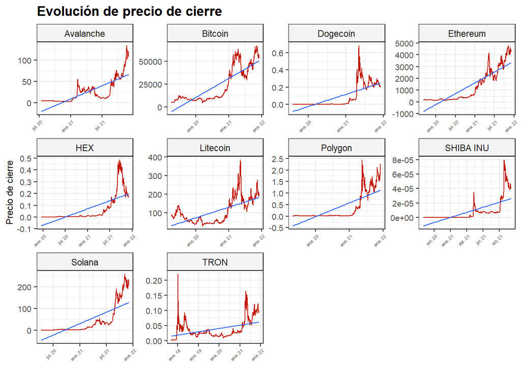

```r
ggplot(data = info_cuantitativa_top, aes(x = Date, y = Close)) +
  geom_line(size = 0.5, color = "#c21807") +
  facet_wrap("Currency", nrow  = 3, scales = "free") +
  scale_x_date(date_labels = "%b %y") +
  ggtitle("Evolución de precio de cierre") +
  geom_smooth(method = "lm", se = FALSE, size = 0.5) +
  theme_bw() +
  theme(axis.text = element_text(size = 8), axis.title =  element_text(size = 9), plot.title = element_text(face = 'bold'), axis.text.x = element_text(angle = 45, vjust = 1, hjust=1, size=4), strip.background=element_rect(colour="black", fill="#f4f4f4")) +
  labs(x = element_blank(), y = "Precio de cierre")
```

Y la gráfica de retornos.

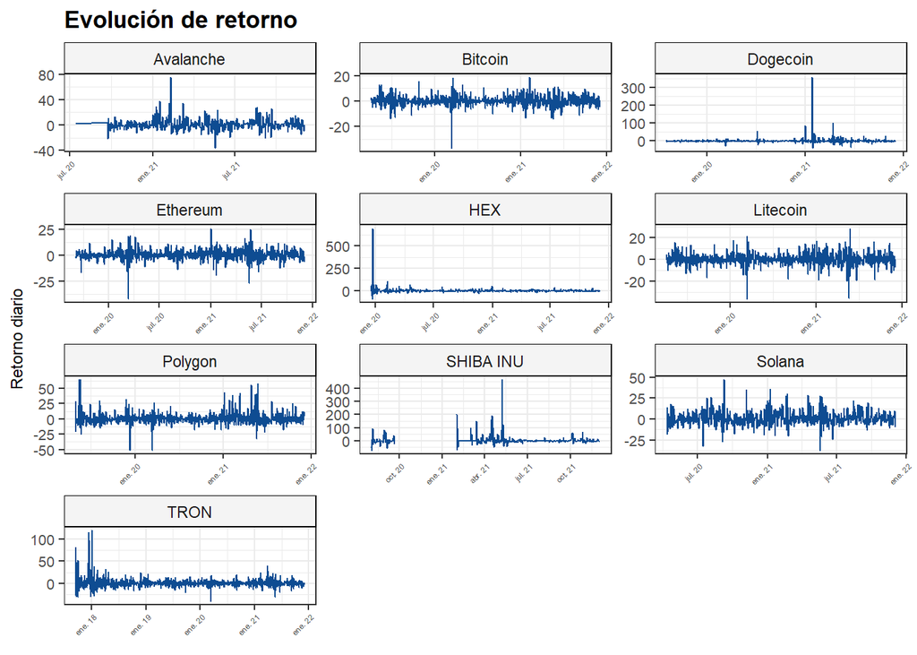

```r
ggplot(data = info_cuantitativa_top) +
  geom_line(aes(x = Date, y = Return_Pctg), size = 0.5, color = "#0E4C92") +
  ggtitle("Evolución de retorno") +
  facet_wrap("Currency", nrow  = 4, scales = "free") +
  scale_x_date(date_labels = "%b %y") +
  theme_bw() +
  theme(axis.text = element_text(size = 8), axis.title =  element_text(size = 9), plot.title = element_text(face = 'bold'), axis.text.x = element_text(angle = 45, vjust = 1, hjust=1, size=4), strip.background=element_rect(colour="black", fill="#f4f4f4")) +
  labs(x = element_blank(), y = "Retorno diario")
```

Las series temporales se pueden dividir en varias componentes: una componente tendencial, una componente estacional y una componente restante. Para cada una de las 10 monedas seleccionadas, vamos a descomponer la serie de los valores de cierre y mostrar sus distintas componentes. Únicamente lo vamos a poder hacer para series para las que disponemas de más de dos años de datos (Bitcoin, Dogecoin, Ethereum, Litecoin, Polygon y TRON)

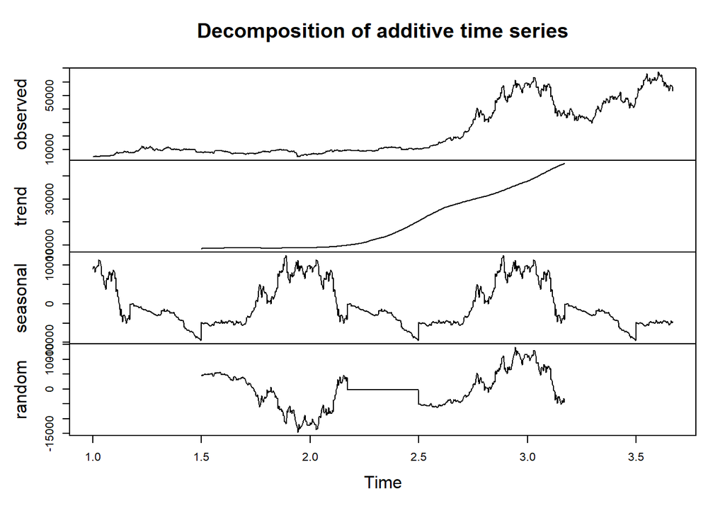

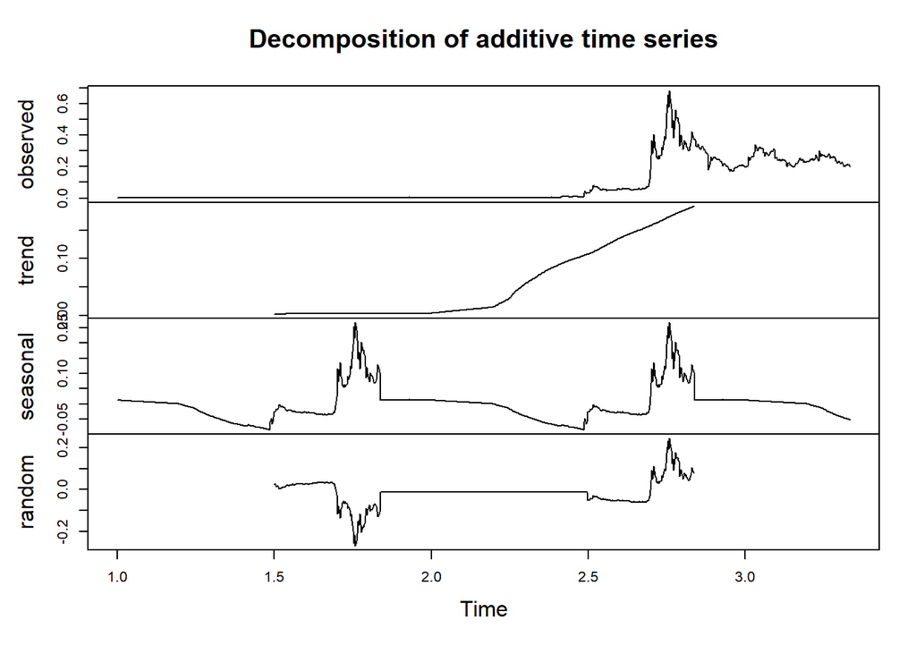

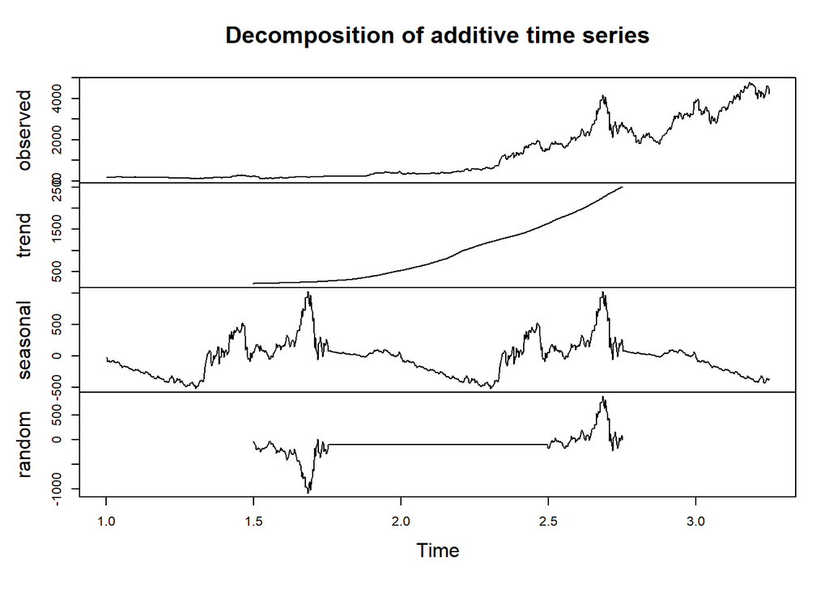

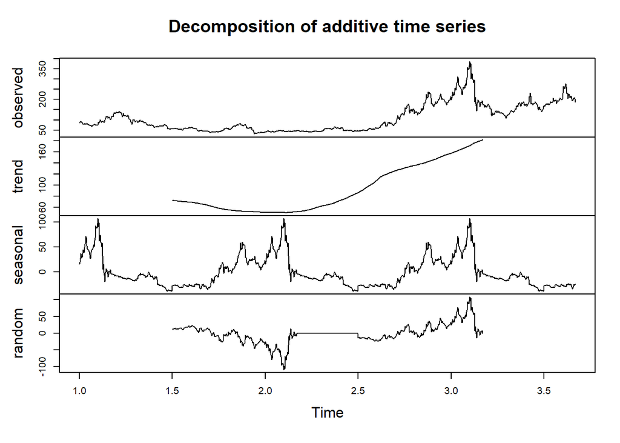

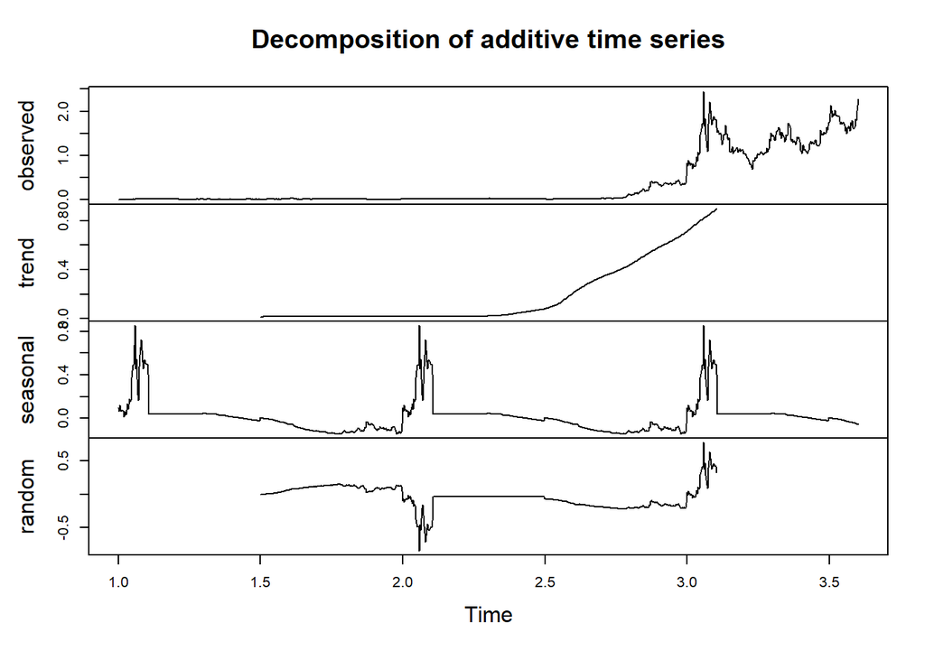

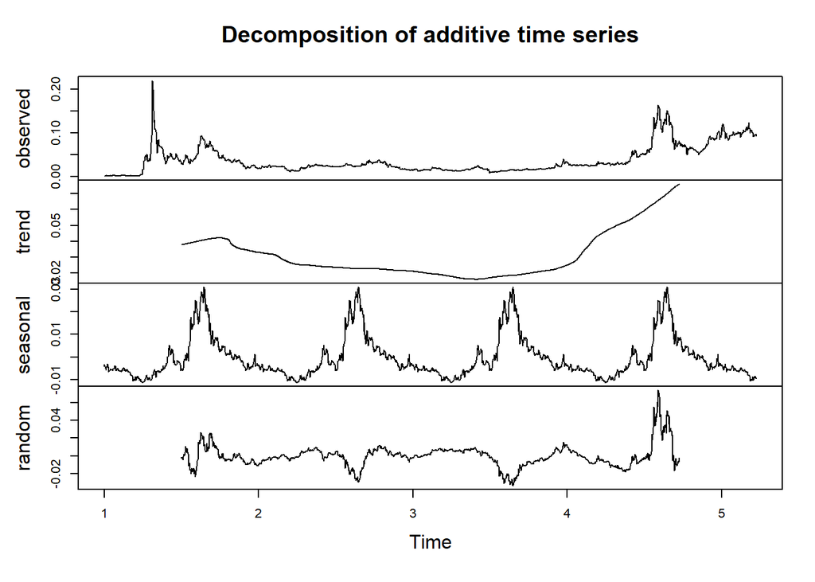

```r
ts_monedas_top_close <- info_cuantitativa %>%
  filter(Currency %in% top_cap$Currency) %>%
  select(Date, Close) %>%
  spread(Currency, Close)

ts_monedas_top_close <- as.xts(ts_monedas_top_close[, -1], order.by = as.Date(ts_monedas_top_close$Date))

for (i in c(2, 3, 4, 6, 7, 10))
{
  plot(decompose(ts(na.omit(ts_monedas_top_close[, i]), frequency = 365)))
}
```

Nos quedamos únicamente con las fechas que tienen valor para todas las monedas y calculamos la matriz de correlación entre los precios de cierre de las distintas monedas. Usamos el coeficiente de correlación de Pearson.

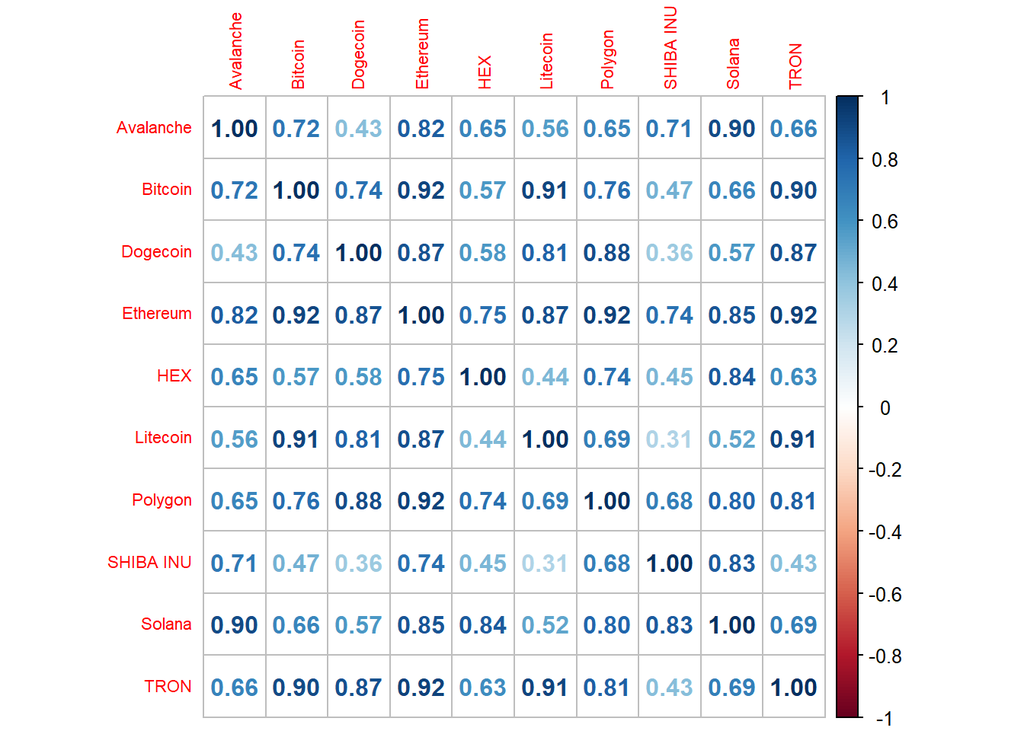

```r
corrplot(cor(ts_monedas_top_close, use = "pairwise.complete.obs"), method = "number", addCoef.col = 1, tl.cex = 0.7)
```

Vemos que Bitcoin, Ethereum, Litecoin y TRON parecen ser las criptomonedas que mayor correlación muestran entre sí. Mostramos la gráfica de los retornos de estas cuatro criptomonedas en el año 2020.

```r
ts_monedas_top_return_2 <- info_cuantitativa %>%
  filter(Currency %in% c("Bitcoin", "Ethereum", "Litecoin", "TRON")) %>%
  select(Date, Return_Pctg) %>%
  spread(Currency, Return_Pctg)

ts_monedas_top_return_2 <- as.xts(ts_monedas_top_return_2[, -1], order.by = as.Date(ts_monedas_top_return_2$Date))

dygraph(ts_monedas_top_return_2["2020/2020"], main = "Retorno diario") %>%
  dyAxis("y", label = "%") %>%
  dyOptions(colors = RColorBrewer::brewer.pal(3, "Set2"))
```

[interactive chart not shown]

## Métricas

### Sharpe Ratio

(Rendimiento Promedio - Tasa de Rendimiento Libre de Riesgo) / Desviación Estándar de los Rendimientos Diarios

- Rendimiento Diario = [(Precio de Cierre Actual - Precio de Cierre del Día Anterior) / Precio de Cierre del Día Anterior] * 100
- Rendimiento libre de riesgo: Necesitas tener una tasa de interés libre de riesgo para usar en tu cálculo. Esto podría ser la tasa de interés de un bono del gobierno a corto plazo.

```r
ts_monedas_top_return <- info_cuantitativa %>%
  filter(Currency %in% top_cap$Currency) %>%
  select(Date, Return_Pctg) %>%
  spread(Currency, Return_Pctg)

ts_monedas_top_return <- as.xts(ts_monedas_top_return[, -1], order.by = as.Date(ts_monedas_top_return$Date))

round(SharpeRatio(ts_monedas_top_return[, , drop = FALSE], Rf = .0003, FUN = "StdDev"), 4)
```

```
##                               Avalanche Bitcoin Dogecoin Ethereum  HEX Litecoin
## StdDev Sharpe (Rf=0%, p=95%):    0.1197  0.0822   0.0708   0.1022 0.09   0.0426
##                               Polygon SHIBA INU Solana   TRON
## StdDev Sharpe (Rf=0%, p=95%):   0.114    0.1454  0.145 0.0661
```

Hemos asumido una tasa de riesgo libre del 0.03%.

El índice de Sharpe mide el rendimiento por unidad de riesgo. Cuanto mayor es su valor mejor es el ratio entre riesgo y rendimiento que tiene una inversión.

### Network Value To Transactions (NVT)

```r
nvt <- info_cuantitativa %>%
  filter(Currency %in% top_cap$Currency) %>%
  group_by(Currency) %>%
  summarize(NVT = sum(`Market Cap`) / sum(Volume))

nvt
```

```
## # A tibble: 10 × 2
##    Currency     NVT
##    <chr>      <dbl>
##  1 Avalanche  11.4
##  2 Bitcoin    12.3
##  3 Dogecoin    6.06
##  4 Ethereum    7.71
##  5 HEX       697.
##  6 Litecoin    1.82
##  7 Polygon     5.46
##  8 SHIBA INU   3.42
##  9 Solana     14.0
## 10 TRON        2.60
```

### Evolución temporal del BTC

Como curiosidad adidional, vamos a visualizar la evolución del Bitcoin.

Para ello convertimos a objeto xts para trabajar con series temporales y creamos el gráfico

```r
info_cuantitativa_ts_bitcoin <- info_cuantitativa %>%
  ungroup() %>%
  filter(Currency == "Bitcoin") %>%
  select(Date, Close, Return_Pctg)

info_cuantitativa_ts_bitcoin <- as.xts(info_cuantitativa_ts_bitcoin[, -1], order.by = as.Date(info_cuantitativa_ts_bitcoin$Date))
```

```r
dygraph(info_cuantitativa_ts_bitcoin$Close, main = "Bitcoin") %>%
  dyAxis("y", label = "%") %>%
  dyOptions(colors = RColorBrewer::brewer.pal(3, "Set2"))
```

[interactive chart not shown]

## Clustering

Vamos a añadir a crypto_summary_by_currency el Sharpe Ratio y el NVT

```r
#Este es un cálculo para crear el SR y NVT de TODAS las criptos.
calculoSR <- info_cuantitativa %>%
  filter(Currency %in% crypto_summary_by_currency$Currency) %>%
  select(Date, Return_Pctg) %>%
  spread(Currency, Return_Pctg)
calculoSR2 <- as.xts(calculoSR[, -1], order.by = as.Date(calculoSR$Date))

filaSR<-round(SharpeRatio(calculoSR2[, , drop = FALSE], Rf = .0003, FUN = "StdDev"), 4)
filaSR<-as.data.frame.table(filaSR)


calculonvt <- info_cuantitativa %>%
  filter(Currency %in% crypto_summary_by_currency$Currency) %>%
  group_by(Currency) %>%
  summarize(NVT = sum(`Market Cap`) / sum(Volume))
```

Ahora añadimos estos valores a crypto_summary_by_currency para hacer el clustering.

```r
crypto_summary_by_currency_clustering <- crypto_summary_by_currency %>% remove_rownames %>% column_to_rownames(var="Currency")
crypto_summary_by_currency_clustering$nvt<-calculonvt$NVT
crypto_summary_by_currency_clustering$SharpeRatio<-filaSR$Freq
```

Tenemos 107 criptomonedas con 5 variables numéricas.

Para que el algoritmo de clasificación tenga sentido, es preciso normalizar cada variable, porque si no el MarketCap tendría mucho más peso que el resto de las variables.

```r
crypto_summary_by_currency_clustering_norm <- scale(crypto_summary_by_currency_clustering)
```

Para determinar el número ideal de clústeres para hacer la división, vamos a utilizar diferentes métodos de estimación.

Empezamos con la silueta y el codo.

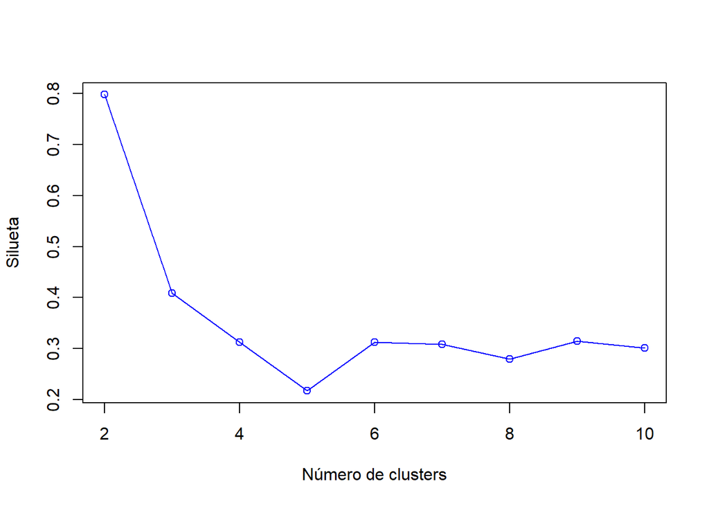

```r
matDist <- daisy(crypto_summary_by_currency_clustering_norm)
resultadosDaisy <- rep(0, 10)
resultadosCodo <- rep(0, 10)
for (i in c(2,3,4,5,6,7,8,9,10))
{
  set.seed(1234)
  ajuste           <- kmeans(crypto_summary_by_currency_clustering_norm, i)
  y_cluster     <- ajuste$cluster
  resultadosCodo[i] <- ajuste$tot.withinss
  silueta            <- silhouette(y_cluster, matDist)
  resultadosDaisy[i] <- mean(silueta[,3])

}
plot(2:10,resultadosDaisy[2:10],type="o",col="blue",xlab="Número de clusters",ylab="Silueta")
```

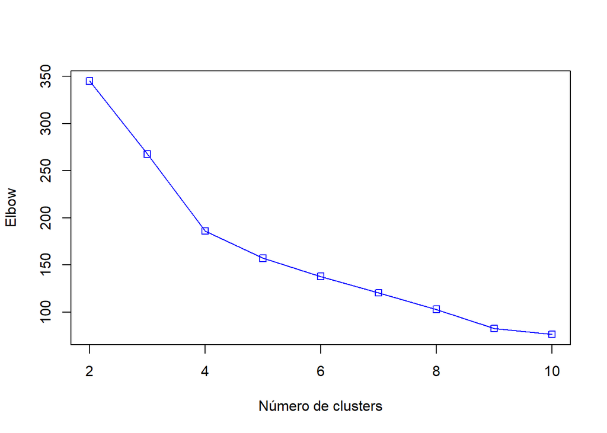

```r
plot(2:10,resultadosCodo[2:10],type="o",col="blue",pch=0,xlab="Número de clusters",ylab="Elbow")
```

Vamos a ver qué sucede con el Bouldin Index

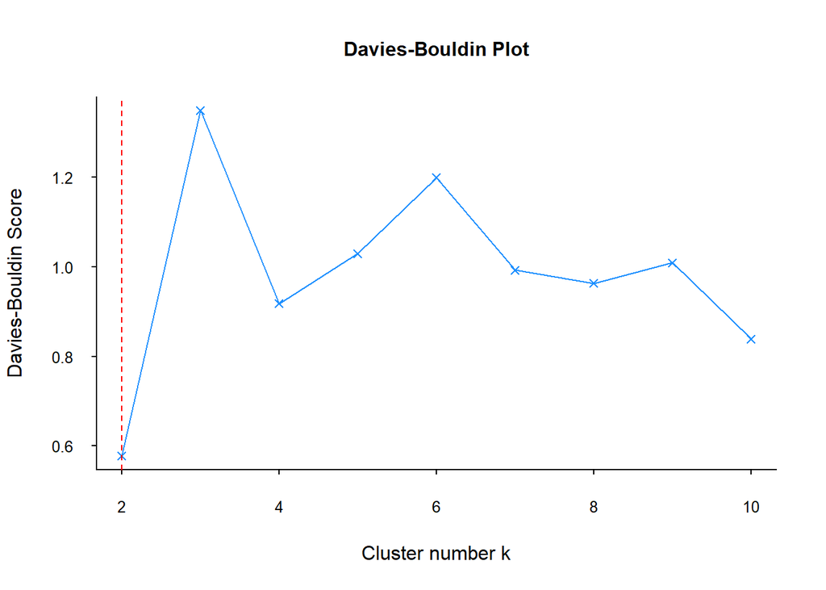

```r
fviz_db <- function(data) {
  k <- c(2:10)
  nb <- NbClust(data, min.nc = 2, max.nc = 10, index = "db", method = "kmeans")
  db <- as.vector(nb$All.index)
  plot(k, db,xlab =  "Cluster number k",
       ylab = "Davies-Bouldin Score",
       main = "Davies-Bouldin Plot", cex.main=1,
       col = "dodgerblue1", cex = 0.9 ,
       lty=1 , type="o" , lwd=1, pch=4,
       bty = "l",
       las = 1, cex.axis = 0.8, tcl  = -0.2)
  abline(v=which(db==min(db)) + 1, lwd=1, col="red", lty="dashed")
}


fviz_db(crypto_summary_by_currency_clustering_norm)
```

Vamos con el CH (Calinski - Harabaz)

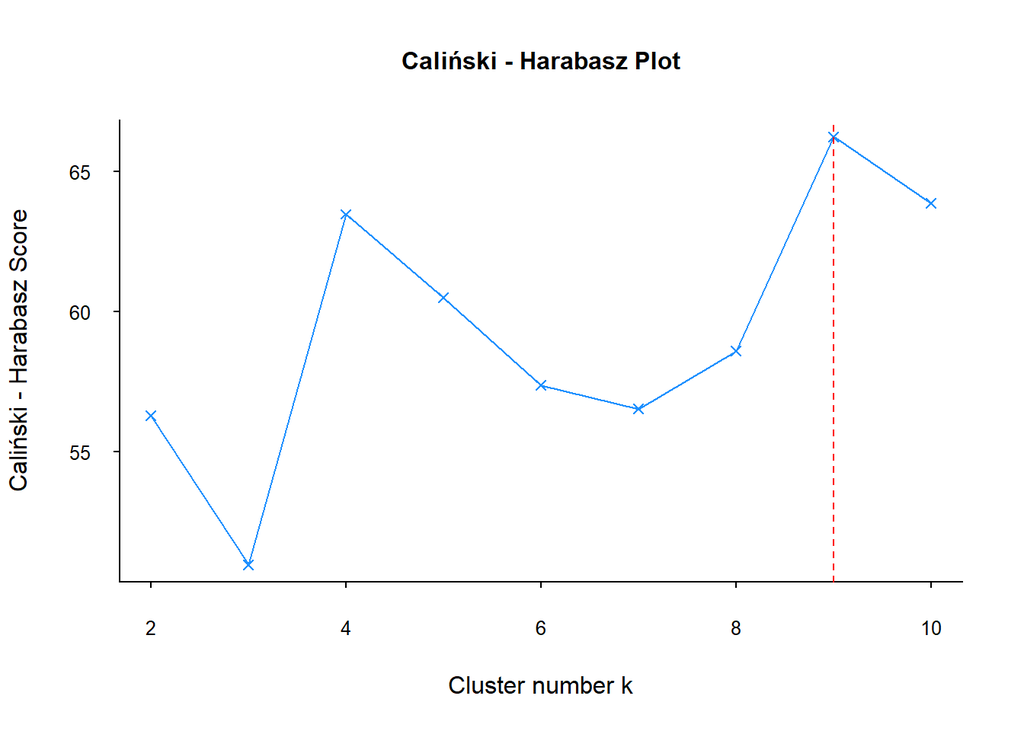

```r
fviz_ch <- function(data) {
  ch <- c()

  for (i in 2:10) {
    set.seed(1234)
    km <- kmeans(data, i)
    ch[i] <- calinhara(data,
                       km$cluster,
                       cn=max(km$cluster)
                       )
  }
  ch <-ch[2:10]
  k <- 2:10
  plot(k, ch,xlab =  "Cluster number k",
       ylab = "Caliński - Harabasz Score",
       main = "Caliński - Harabasz Plot", cex.main=1,
       col = "dodgerblue1", cex = 0.9 ,
       lty=1 , type="o" , lwd=1, pch=4,
       bty = "l",
       las = 1, cex.axis = 0.8, tcl  = -0.2)
  abline(v=which(ch==max(ch)) + 1, lwd=1, col="red", lty="dashed")
}

fviz_ch(crypto_summary_by_currency_clustering_norm)
```

Según el algoritmo utilizado, el número de clústers recomendado varía ligeramente. Sin embargo, en general 2 y 4 parecen estimaciones bastante aceptadas.

Por tanto, vamos a visualizar estas agrupaciones con el algoritmo kmeans y veamos qué agrupaciones quedan

```r
# 2 clústers
set.seed(1234)
result2Clusters <- kmeans(crypto_summary_by_currency_clustering_norm,centers = 2)
result2Clusters$centers
```

```
##   Market Cap     Volume  Volatility          nvt SharpeRatio
## 1  6.4540727  6.8580622 -1.27536237 -0.271985309  0.60180634
## 2 -0.1229347 -0.1306298  0.02429262  0.005180673 -0.01146298
```

Vemos que se generan 2 grupos. Destaca el primero con una altísima influencia de MarketCap y Volumen.

Mostramos los resultados en forma de tabla y vemos que uno de los grupos solo tiene 2 elementos

```r
result2Clusters$cluster %>%table()
```

```
## .
##   1   2
##   2 105
```

Visualizamos a qué grupo pertenece cada moneda

```r
result2Clusters$cluster
```

```
##             ASTA             AXEL        Aeternity             Aion
##                2                2                2                2
##         Algorand             Auto        Avalanche             BORA
##                2                2                2                2
##       BarnBridge       BitTorrent          Bitcoin            Bread
##                2                2                1                2
##            Carry        Cellframe           ChainX           Chiliz
##                2                2                2                2
##            Civic          Conflux      Convergence           Cortex
##                2                2                2                2
##              DAD             Dash             Dent             Dock
##                2                2                2                2
##         Dogecoin     Dogelon Mars          EFFORCE          Elitium
##                2                2                2                2
##         Ethereum Ethereum Classic          Everest          Exeedme
##                1                2                2                2
##            FLETA           Fantom          ForTube         Frontier
##                2                2                2                2
##           Fusion            GAMEE             Gala          Gitcoin
##                2                2                2                2
##           Glitch              HEX             HUNT        Handshake
##                2                2                2                2
##           Helium             Holo            Hydra             IOST
##                2                2                2                2
##             IOTA              Kin           Klever           Komodo
##                2                2                2                2
##           Kusama          LATOKEN             LINK           Lamden
##                2                2                2                2
##        Lightning           Linear          Liquity         Litecoin
##                2                2                2                2
##            Lotto             MATH              MCO              MXC
##                2                2                2                2
##           Marlin         Metadium            Metal             Mist
##                2                2                2                2
##           Monero              Neo             Nexo            Nexus
##                2                2                2                2
##              OKB          Opacity             Oxen           Oxygen
##                2                2                2                2
##         Pangolin          Polygon         Populous            Propy
##                2                2                2                2
##           Proton            Qcash             Qtum          Rarible
##                2                2                2                2
##        Ravencoin              Ren          Request        SHIBA INU
##                2                2                2                2
##              SIX            SOLVE             SORA           Secret
##                2                2                2                2
##           Solana           StormX           Strike         Syntropy
##                2                2                2                2
##             TRON             TROY     UNUS SED LEO            Ultra
##                2                2                2                2
##             VITE             Velo           Vesper              WAX
##                2                2                2                2
##             Zano            Zenon          Zigcoin
##                2                2                2
```

Vemos que hay un grupo muy pequeño, con solo dos elementos (Ethereum y Bitcoin). Estas dos criptomonedas tienen unos valores altísimos de MarketCap y Volumen, por lo que tiene sentido que se genere un clúster para ellos.

Vamos a ver una representación de los clusters en el espacio.

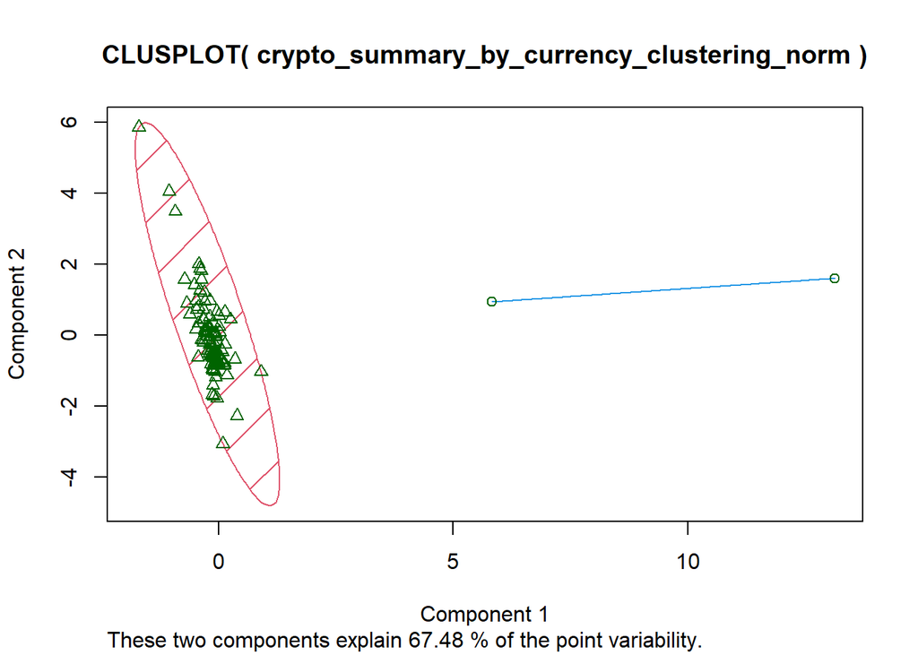

```r
clusplot(crypto_summary_by_currency_clustering_norm, result2Clusters$cluster, color=T, shade=T, labels=0, lines=0)
```

```
## Too few points to calculate an ellipse
```

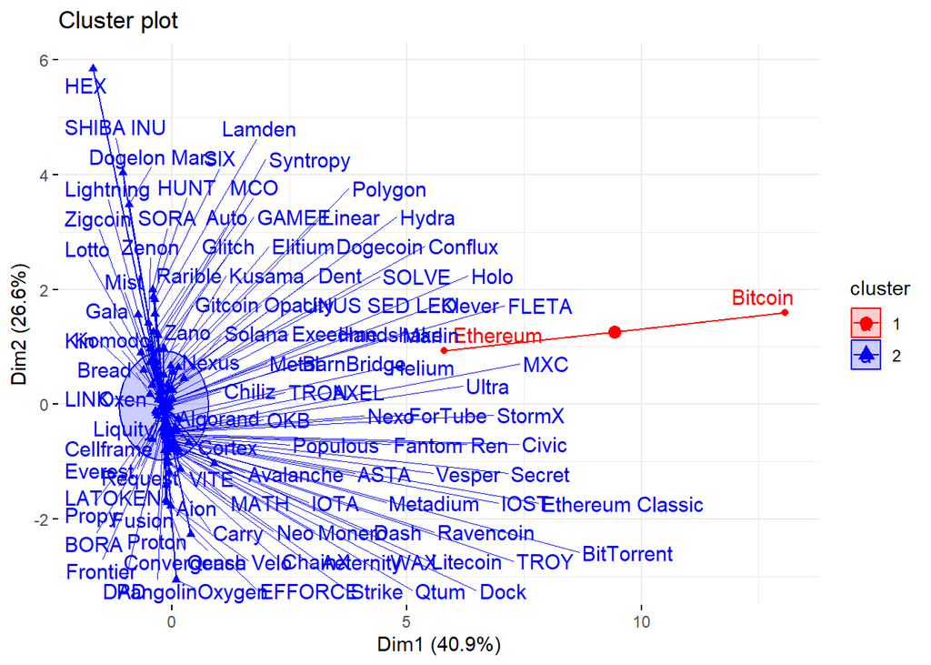

```r
fviz_cluster(result2Clusters, data = crypto_summary_by_currency_clustering_norm,
             palette = c("#FF0000", "#0000FF"),
             ellipse.type = "euclid", # Concentration ellipse
             star.plot = TRUE, # Add segments from centroids to items
             repel = TRUE, # Avoid label overplotting (slow)
             ggtheme = theme_minimal())
```

Lo que vemos haciendo dos grupos es que hay un grupo de dos monedas (Bitcoin y Ethereum), que son tan diferentes de las demás que es suficiente para crear un grupo. Esta conclusión es muy interesante, porque nos indica que son monedas extraordinarias.

Vamos a hacer lo mismo con 4 grupos y vemos qué sucede.

```r
set.seed(1234)
result4Clusters <- kmeans(crypto_summary_by_currency_clustering_norm,centers = 4)
result4Clusters$centers
```

```
##   Market Cap     Volume Volatility         nvt SharpeRatio
## 1  6.4540727  6.8580622 -1.2753624 -0.27198531  0.60180634
## 2  0.1109359 -0.1661838  3.5735407  8.62036563  0.03353485
## 3 -0.1197914 -0.1329696  0.5641253 -0.17272421  0.91100869
## 4 -0.1282880 -0.1287439 -0.3402966 -0.02292235 -0.54326482
```

```r
result4Clusters$cluster
```

```
##             ASTA             AXEL        Aeternity             Aion
##                4                4                4                4
##         Algorand             Auto        Avalanche             BORA
##                4                3                4                4
##       BarnBridge       BitTorrent          Bitcoin            Bread
##                3                4                1                4
##            Carry        Cellframe           ChainX           Chiliz
##                4                4                4                3
##            Civic          Conflux      Convergence           Cortex
##                4                3                4                4
##              DAD             Dash             Dent             Dock
##                4                4                3                4
##         Dogecoin     Dogelon Mars          EFFORCE          Elitium
##                3                3                4                4
##         Ethereum Ethereum Classic          Everest          Exeedme
##                1                4                4                3
##            FLETA           Fantom          ForTube         Frontier
##                3                4                4                4
##           Fusion            GAMEE             Gala          Gitcoin
##                4                3                3                3
##           Glitch              HEX             HUNT        Handshake
##                3                2                3                3
##           Helium             Holo            Hydra             IOST
##                4                3                3                4
##             IOTA              Kin           Klever           Komodo
##                4                4                4                4
##           Kusama          LATOKEN             LINK           Lamden
##                3                4                4                3
##        Lightning           Linear          Liquity         Litecoin
##                3                3                4                4
##            Lotto             MATH              MCO              MXC
##                4                4                3                4
##           Marlin         Metadium            Metal             Mist
##                3                4                3                3
##           Monero              Neo             Nexo            Nexus
##                4                4                4                3
##              OKB          Opacity             Oxen           Oxygen
##                4                3                4                4
##         Pangolin          Polygon         Populous            Propy
##                4                3                4                4
##           Proton            Qcash             Qtum          Rarible
##                4                4                4                3
##        Ravencoin              Ren          Request        SHIBA INU
##                4                4                4                3
##              SIX            SOLVE             SORA           Secret
##                3                3                3                4
##           Solana           StormX           Strike         Syntropy
##                3                4                4                3
##             TRON             TROY     UNUS SED LEO            Ultra
##                4                4                4                4
##             VITE             Velo           Vesper              WAX
##                4                4                4                4
##             Zano            Zenon          Zigcoin
##                3                3                3
```

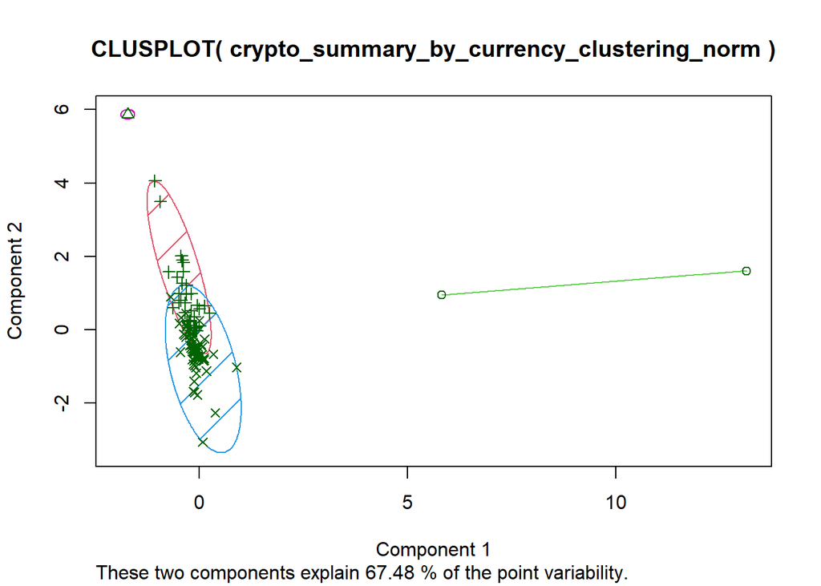

```r
clusplot(crypto_summary_by_currency_clustering_norm, result4Clusters$cluster, color=T, shade=T, labels=0, lines=0)
```

```
## Too few points to calculate an ellipse
## Too few points to calculate an ellipse
```

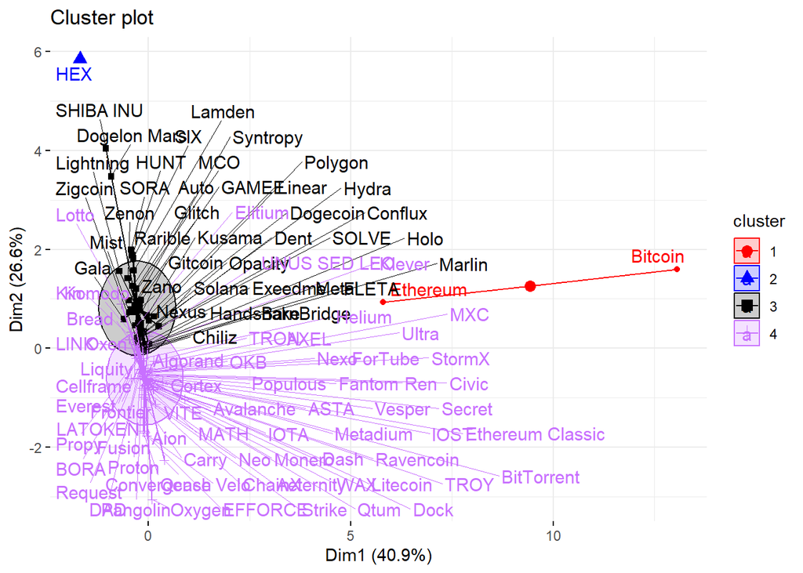

```r
fviz_cluster(result4Clusters, data = crypto_summary_by_currency_clustering_norm,
             palette = c("#FF0000", "#0000FF",  "#000000", "#C870FF"),
             ellipse.type = "euclid", # Concentration ellipse
             star.plot = TRUE, # Add segments from centroids to items
             repel = TRUE, # Avoid label overplotting (slow)
             ggtheme = theme_minimal())
```

Al hacer cuatro grupos, vemos que se mantiene el grupo anterior de Bitcoin y Ethereum y se crea un grupo nuevo para “HEX”, que tiene un valor anormalmente elevado de NVT.

El resto de las criptomonedas se dividen en los grupos 3 y 4.

Por último, hacemos la matriz de correlaciones.

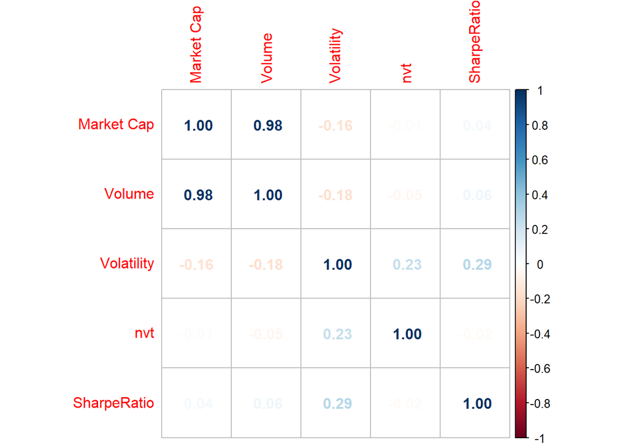

```r
corrplot(cor(crypto_summary_by_currency_clustering), method='number')
```

De esta matriz observamos que hay una altísima correlación entre el MarketCap y el Volumen.

Por el contrario podemos ver que las métricas de NVT SharpeRatio están más relacionadas con la volatilidad.

Además, el volumen y el MarketCap tienen una relación inversa con la volatilidad.

## Diagramas en otros formatos.

Para completar el análisis de los datos, se incluyen en la entrega gráficos generados en PowerBI y en Excel en los ficheros.

Para ello se realizó una exportación a Excel del dataset crypto_summary_by_currency para representar los siguientes diagramas con PowerBI.

- Sharpe Ratio: Diagrama que indica por cada criptomoeda su valor.
- Información global: Volumen y MarketCap por cada criptomoneda.
- Porcentaje de volumen de operaciones sobre el total. Amplia mayoría de BTC y ETH
- Posibles valores inflados. NVT alto sobre volumen de operaciones bajo.
- Posibles valores burbuja.
- Diagramas con el volumen de cada cluster en función del número de monedas por grupo

Adicionalmente, se facilita un diagrama en Excel con el Market Cap de las criptomonedas separadas por los grupos generados a partir de los 4 grupos o clusters generados en este dataset